# TAREFA 2 - Análise Multivariada

Márcia H. Barbian

2025

```r
knitr::opts_chunk$set(echo = TRUE, warning = FALSE, message = FALSE)
```

# Exercicio 1

Quais os estimadores de máxima verossimilhança de $\boldsymbol{\mu}$ e $\boldsymbol{\Sigma}$ quando a amostra provém de uma distribuição normal multivariada.

## Resposta 1

$$X_i \sim \mathcal{N}_p(\boldsymbol{\mu}, \boldsymbol{\Sigma}), i =
1,..., n$$
Para $p$ sendo a dimensão da normal, $\boldsymbol{\mu}$ e $\boldsymbol{\Sigma}$ sendo respectivamente o vetor de médias e a matriz de convariâncias.

Temos a F.D.P de $X_i$:
$$f(X_i) = \frac{1}{(2\pi)^{p/2} |\Sigma|^{1/2}} e^{(-\frac{1}{2}(X_i -
\mu)'\Sigma^{-1}(X_i-\mu))}$$
Aplicando a função de verossimilhança:

$$L(\boldsymbol{\mu}, \boldsymbol{\Sigma}) = \prod_{i = 1}^{n} f(X_i)$$

Aplicando o log:

$$\ell(\boldsymbol{\mu}, \boldsymbol{\Sigma}) = -\frac{np}{2} \log(2\pi) -
\frac{n}{2} \log|\boldsymbol{\Sigma}| - \frac{1}{2} \sum_{i=1}^n
(\mathbf{X}_i - \boldsymbol{\mu})' \boldsymbol{\Sigma}^{-1}
(\mathbf{X}_i - \boldsymbol{\mu})$$

### EMV de $\boldsymbol{\mu}$

Resolvendo para $\boldsymbol{\mu}$, derivamos $\ell$ em relação ao parâmetro e igualamos a zero para maximizar:

$$\frac{\partial\ell}{\partial\boldsymbol{\mu}} = \sum_{i=1}^n
(\mathbf{X}_i - \boldsymbol{\mu})' \boldsymbol{\Sigma}^{-1}
(\mathbf{X}_i - \boldsymbol{\mu}) = 0 \newline
\frac{\partial\ell}{\partial\boldsymbol{\mu}}= \sum_{i=1}^n
\boldsymbol\Sigma^{-1}(X_i - \boldsymbol\mu) = 0$$

Como a matriz $\boldsymbol\Sigma$ é invertível podemos multiplicar ambos os lados chegando em:

$$\sum_{i=1}^n (X_i - \boldsymbol\mu) = 0 \newline
\sum_{i=1}^n X_i - n\boldsymbol\mu = 0 \newline
\boldsymbol\mu= \frac{1}{n} \sum_{i=1}^n X_i$$

Portanto o estimador de máxima verossimilhança de $\boldsymbol{\mu}$ é a média amostral; $\boldsymbol{\hat\mu} = \bar X$

### EMV de $\boldsymbol{\Sigma}$

Repetimos o mesmo processo do anterior, mas agora tendo a matriz $\boldsymbol{\Sigma}$ como referência:

$$\frac{\partial \ell}{\partial \boldsymbol{\Sigma}} = -
\frac{n}{2}\boldsymbol{\Sigma}^{-1}+\frac{1}{2}\sum_{i=1}^n\boldsymbol{\Sigma}^{-1}(X_i
- \boldsymbol \mu)(X_i- \boldsymbol \mu)'\boldsymbol \Sigma^{-1} = 0
\newline
- \frac{n}{2}I+\frac{1}{2}\sum_{i=1}^n\boldsymbol{\Sigma}^{-1}(X_i -
\boldsymbol \mu)(X_i- \boldsymbol \mu)'\boldsymbol \Sigma^{-1}
\boldsymbol \Sigma= 0 \newline
\boldsymbol{\hat\Sigma} = \frac{1}{n} \sum_{i=1}^n(X_i - \boldsymbol
\mu)(X_i -\boldsymbol \mu)'$$
Substituímos $\boldsymbol \mu$ pelo seu estimador calculado anteriormente para chegarmos no EMV de $\boldsymbol \Sigma$:

$$\boldsymbol{\hat\Sigma} = \frac{1}{n} \sum_{i=1}^n(X_i - \bar X)(X_i -
\bar X)'$$

# Exercicio 2

Faça os seguintes exercícios do capítulo 4 do livro Applied Multivariate Statistical Analysis.

## a) 4.1

Considere uma distribuição normal bivariada com $\mu_{1}=1$,$\mu_{2}=3$,$\sigma_{11}=2$,$\sigma_{22}=1$ e $p_{12}=-0.8$.

### a) Escreva a densidade da normal bivariada:

1.1 - Encontrar $\sum$:

Assumindo que $\sigma_{11}=2$ é a variância e não o desvio padrão (conforme pag 151 do livro Exemplo 4.1)

$$\sum = \begin{bmatrix}
\sigma_{1}^2 & p*\sigma_{1}*\sigma_{2} \\
p*\sigma_{1}*\sigma_{2} & \sigma_{2}^2
\end{bmatrix}=
\begin{bmatrix}
2 & -0.8\sqrt{2}\\
-0.8\sqrt{2} & 1
\end{bmatrix}$$
1.2 - Calcular o determinante:
$$2*1 - (-0.8\sqrt{2})(-0.8\sqrt{2})= 0.72$$
1.3 - Inversa da matriz de covariancia:

$$Σ^{-1}= \frac{1}{0.72}\begin{bmatrix}
1 & -0.8\sqrt{2} \\
-0.8\sqrt{2} & 2
\end{bmatrix}=\begin{bmatrix}
\frac{1}{0.72} & \frac{-0.8\sqrt{2}}{0.72} \\
\frac{-0.8\sqrt{2}}{0.72} & \frac{2}{0.72}
\end{bmatrix}$$
1.4 - Fórmula da densidade:

1.4.1 - A distância de Mahalanobis

$$d^{2}(\mathbf{x},\mathbf{\mu})=(\mathbf{x}-\mathbf{\mu})'Σ^{-1}(\mathbf{x}-\mathbf{\mu})$$
$$d^{2}(\mathbf{x},\mathbf{\mu})=[x_{1}-1 \text{ } x_{2}-3]
\begin{bmatrix}
\frac{1}{0.72} & \frac{-0.8\sqrt{2}}{0.72} \\
\frac{-0.8\sqrt{2}}{0.72} & \frac{2}{0.72}
\end{bmatrix}
\begin{bmatrix}
x_{1}-1 \\
x_{2}-3
\end{bmatrix}$$

1.4.2 - fórmula da densidade final

$$f(x_{1},x_{2})=\frac{1}{2\pi\sqrt{0.72}}exp(\frac{-1}{2}[x_{1}-1 \text{
} x_{2}-3]
\begin{bmatrix}
\frac{1}{0.72} & \frac{-0.8\sqrt{2}}{0.72} \\
\frac{-0.8\sqrt{2}}{0.72} & \frac{2}{0.72}
\end{bmatrix}
\begin{bmatrix}
x_{1}-1 \\
x_{2}-3
\end{bmatrix})$$

### b) Escreva a expressão da distância estatística ao quadrado como uma função quadrática de $x_{1}$ e $x_{2}$.

$$\begin{bmatrix}
\frac{1}{0.72} & \frac{-0.8\sqrt{2}}{0.72} \\
\frac{-0.8\sqrt{2}}{0.72} & \frac{2}{0.72}
\end{bmatrix}
\begin{bmatrix}
x_{1}-1 \\
x_{2}-3
\end{bmatrix}=
\begin{bmatrix}
\frac{1}{0.72}(x_{1}-1) + \frac{-0.8\sqrt{2}}{0.72}(x_{2}-3) \\
\frac{-0.8\sqrt{2}}{0.72}(x_{1}-1) + \frac{2}{0.72}(x_{2}-3)
\end{bmatrix}[x_{1}-1 \text{ } x_{2}-3]$$

$$(x_{1}-1)[\frac{1}{0.72}(x_{1}-1)+\frac{-0.8\sqrt{2}}{0.72}(x_{2}-3)]+(x_{2}-3)[\frac{-0.8\sqrt{2}}{0.72}(x_{1}-1)+\frac{2}{72}(x_{2}-3)]$$

$$\frac{1}{0.72}(x_{1}-1)^{2}-\frac{2\sqrt{2}}{0.90}(x_{1}-1)(x_{2}-3)+\frac{2}{0.72}(x_{2}-3)^2$$

## b) 4.19

Seja $X_{1},x_{2}...X_{20}$ uma amostra aleatória de tamanho n=20 de uma $N_{6}(\mathbf{\mu},\mathbf{\sum})$ população. Especifique cada um dos seguintes completamente:

### a) A distribuição de: $(\mathbf{x_{1}}-\mathbf{\mu})'Σ^{-1}(\mathbf{x_{1}}-\mathbf{\mu})$

A distância de Mahalanobis mede a distância quadrática de $x_{1}$ á sua média (ajustada por correlações) e essa distância segue uma distribuição Qui-Quadrado com 6 graus de liberdade porque equivale a somar 6 variáveis normais padrão ao quadrado.

### b) A distribuição de $\bar{X}$ e $\sqrt{n}(\bar{X}-\mu)$:

Como o vetor $\mathbf{X}$ é definido como sendo variáveis normais de tamanho n=20 a média de $\mathbf{X}$ segue uma distribuição normal multivariada. $\mathbf{\bar{X}} \sim N(\mu,\frac{\sum}{20})$

A distribuição de $\sqrt{n}(\bar{X}-\mu)$ segue uma distribução Normal. Conforme resultado anterior $(\bar{X}-\mu)\sim N(0,\frac{\sum}{20})$ multiplicando por $\sqrt{20}$ fica $\sqrt{20}(\bar{X}-\mu) \sim N(0,\sum)$

### c) A distribuição de $(n-1)\mathbf{S}$

Conforme visto em sala de aula a Matriz de covariância da amostra segue uma distribuição de Wishart.

# Exercício 3

Os dados de palmerpenguins contêm medidas para três espécies de pinguins observadas em três ilhas no arquipélago de Palmer, na Antártica. Esses dados foram coletados de 2007 a 2009 pela Dra. Kristen Gorman no Programa de Pesquisa Ecológica da Estação Palmer. Os dados foram importados diretamente do Portal de Dados Ambientais (EDI).

O conjunto de dados palmerpenguins contém 8 variáveis e 344 pinguins.

```r
## -- CORE PACKAGES -- ##
library(palmerpenguins)
library(mvnormtest)
library(ISLR)
library(tidyverse)
library(GGally)
library(qqplotr)
library(mvShapiroTest)


## -- NOSSO BD
# str(penguins)
# names(penguins)

df = penguins[,c("bill_length_mm", "bill_depth_mm", "flipper_length_mm" , "body_mass_g",    "species" )]
```

## a)

Podemos dizer que as variáveis bill_length_mm, bill_depth_mm, flipper_length_mm e body_mass_g possuem distribuição normal multivarida? Justifique a sua resposta.

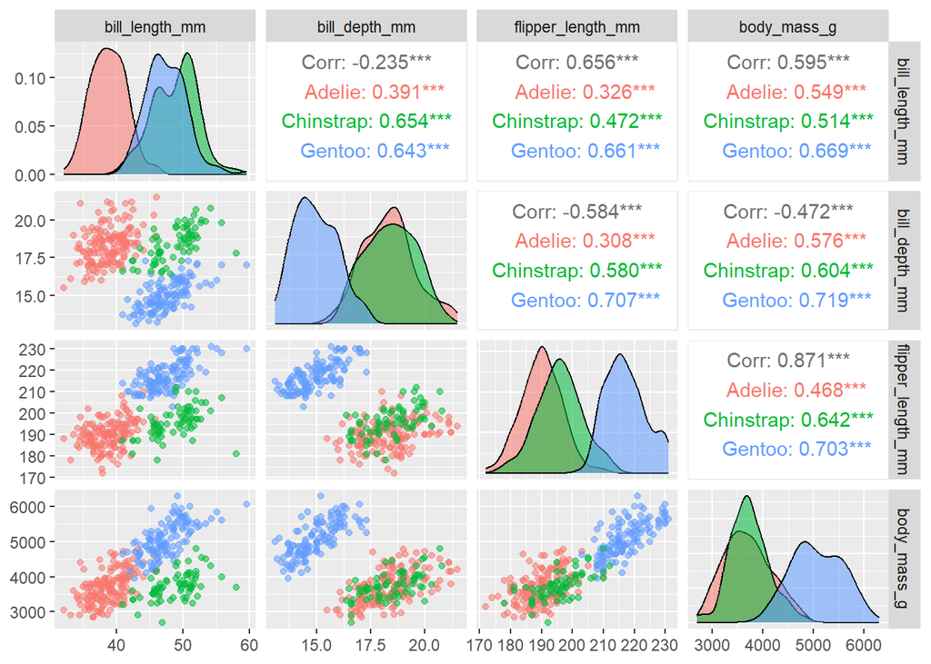

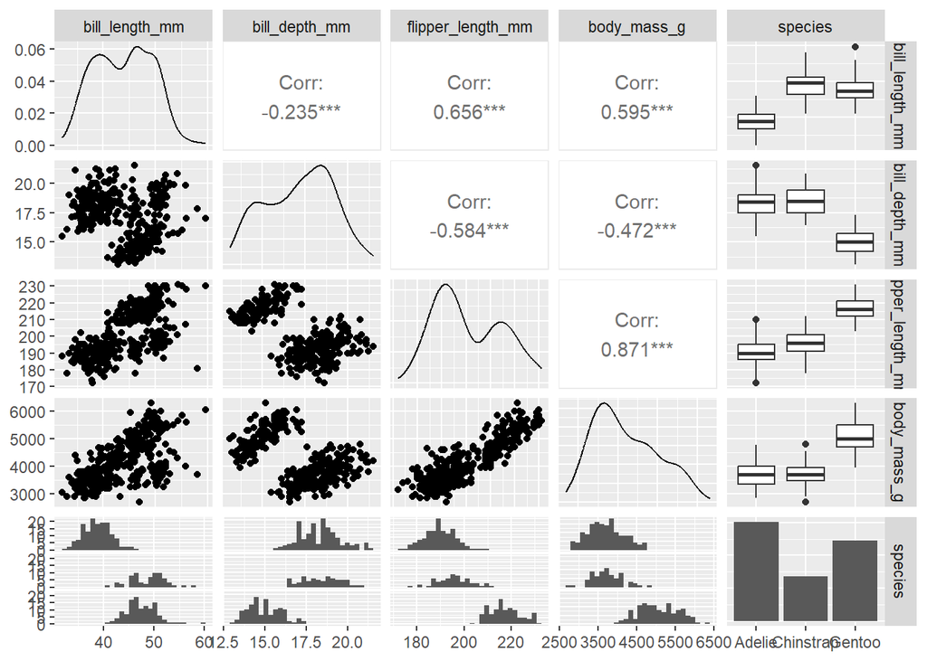

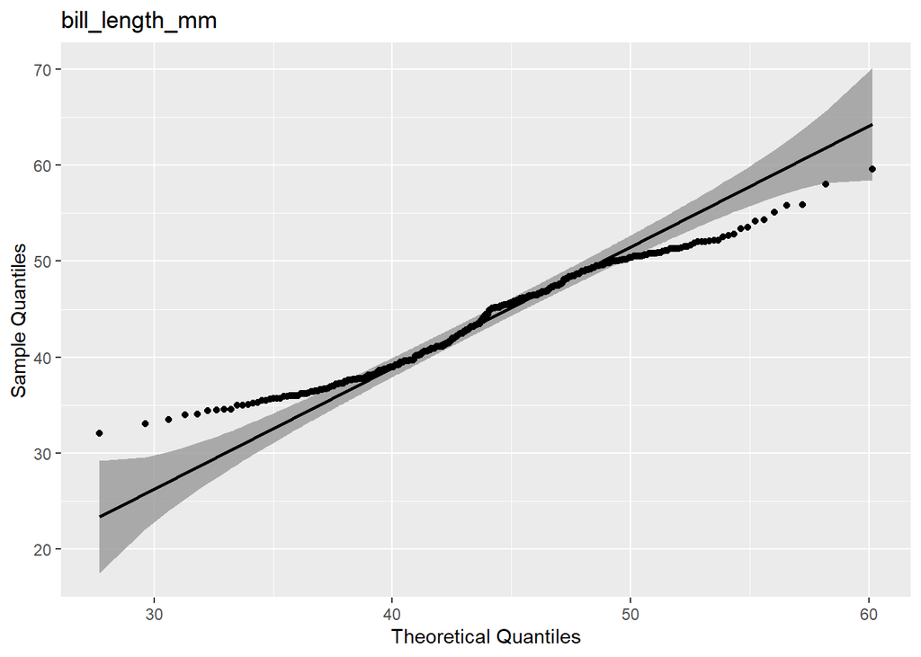

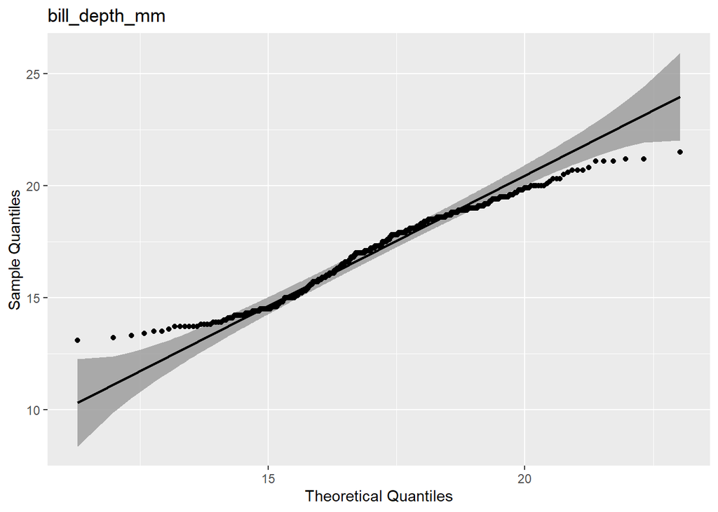

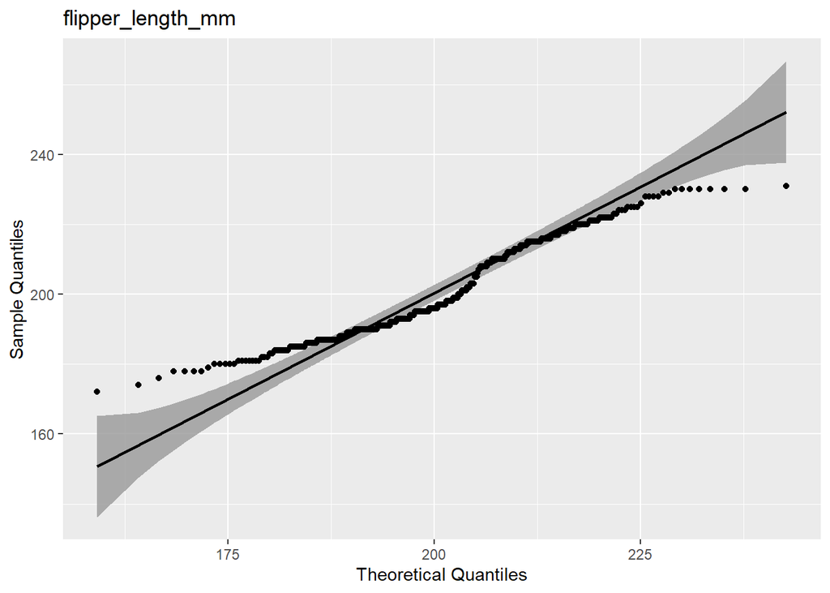

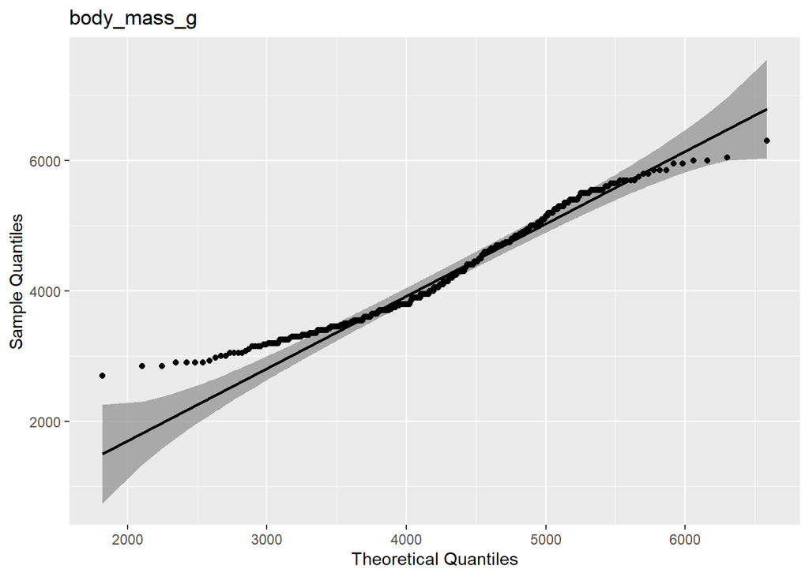

Primeiro podemos analisar as variáveis de forma univariada a fim de verificar se elas são normalmente distribuidas! Através dos qqplots conseguimos ver de forma mais clara que nenhuma possui um comportamento normal!

Podemos ver se o teste de shapiro-wilk rejeita também a hipótese de normalidade das variáveis.

Nossa $H_0$ é que a variável segue uma distribuição normal e a $H_1$ é que não segue.

```
##
##  Shapiro-Wilk normality test
##
## data:  df.semna$bill_length_mm
## W = 0.97485, p-value = 1.12e-05
```

```
##
##  Shapiro-Wilk normality test
##
## data:  df.semna$bill_depth_mm
## W = 0.97258, p-value = 4.419e-06
```

```
##
##  Shapiro-Wilk normality test
##
## data:  df.semna$flipper_length_mm
## W = 0.95155, p-value = 3.54e-09
```

```
##
##  Shapiro-Wilk normality test
##
## data:  df.semna$body_mass_g
## W = 0.95921, p-value = 3.679e-08
```

Podemos ver que todas as variáveis foram rejeitadas, ou seja, não possuem distribuição normal!

Vamos utilizar o teste de shapiro-wilk visto em aula para verificar a normalidade multivariada!!

```
##
##  Generalized Shapiro-Wilk test for Multivariate Normality by
##  Villasenor-Alva and Gonzalez-Estrada
##
## data:  as.matrix(df.semna[, -5])
## MVW = 0.97181, p-value < 2.2e-16
```

Podemos ver que a hipótese nula de normalidade multivariada foi rejeitada! Ou seja não podemos dizer que nossas variáveis possuem distribuição normal multivariada!

## b)

Há algum outlier nesse banco de dados? Justifique a sua resposta.

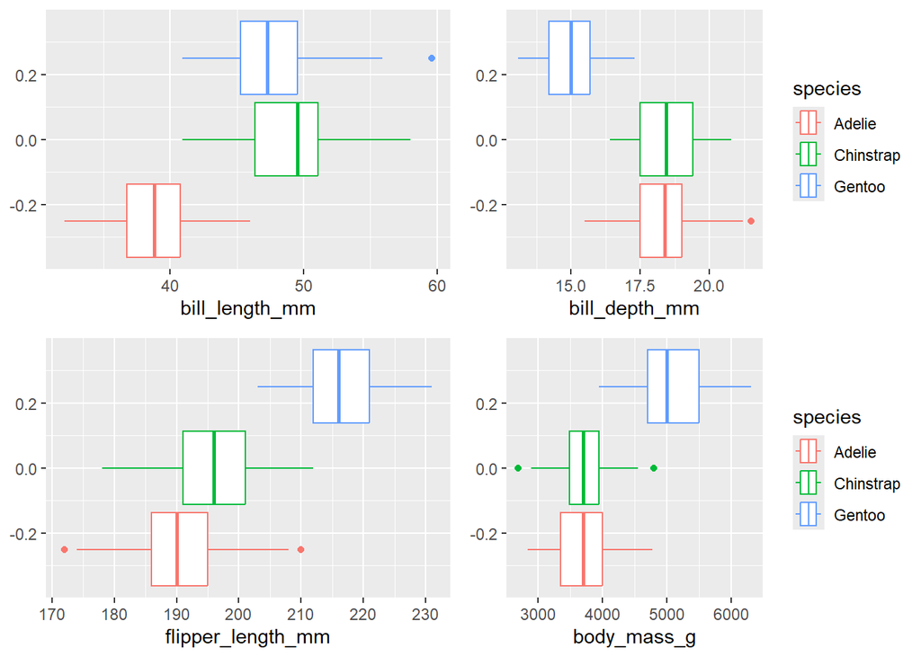

Nossos boxplots sustentados com a análise gráfica feita na questão anterior utilizando ggpairs para visualizar a dispersão das variáveis, conseguimos ver que todas as variáveis possuem algum outlier!

## c)

Faça um teste de hipóteses para comparar se a médias das variáveis bill_length_mm, bill_depth_mm, flipper_length_mm e body_mass_g é a mesma para as diferentes espécies de pinguins, qual a sua conclusão?

O teste de hipóteses para comparar se as médias das variáveis é a mesma para diferentes espécies é a MANOVA. Estamos comparando mais de uma variável de cada vez, por isso é um teste multivariado.

ou seja,

$H_0: \mu_{1} = \mu_{2} = \mu_{3}$

$H_1: \mu_{1} \neq \mu_{2} \neq \mu_{3}$

```
## # A tibble: 3 × 5
##   species   bill_length_mm bill_depth_mm flipper_length_mm body_mass_g
##   <fct>              <dbl>         <dbl>             <dbl>       <dbl>
## 1 Adelie              38.8          18.3              190.       3701.
## 2 Chinstrap           48.8          18.4              196.       3733.
## 3 Gentoo              47.5          15.0              217.       5076.
```

```
## Call:
##    manova(cbind(df.semna$bill_length_mm, df.semna$bill_depth_mm,
##     df.semna$flipper_length_mm, df.semna$body_mass_g) ~ df.semna$species,
##     mu = c(0, 0, 0, 0))
##
## Terms:
##                 df.semna$species Residuals
## resp 1                      7194      2970
## resp 2                       904       426
## resp 3                     52473     14953
## resp 4                 146864214  72443483
## Deg. of Freedom                2       339
##
## Residual standard errors: 2.959853 1.120824 6.641529 462.2744
## Estimated effects may be unbalanced
```

```
##                   Df Pillai approx F num Df den Df    Pr(>F)
## df.semna$species   2 1.6366   379.49      8    674 < 2.2e-16 ***
## Residuals        339
## ---
## Signif. codes:  0 '***' 0.001 '**' 0.01 '*' 0.05 '.' 0.1 ' ' 1
```

Dado que o p-valor da MANOVA foi menor que 0.05, rejeitamos a hipótese nula de que as médias das variáveis são iguais para as diferentes espécies de pinguins.

## d)

Faça um teste de hipóteses para comparar se a médias das as variáveis bill_length_mm, bill_depth_mm, flipper_length_mm e body_mass_g é a mesma para os diferentes sexos dos pinguins, qual a sua conclusão?

Ainda utilizando a MANOVA neste exercício, pois ainda estamos comparando mais de uma variável de cada vez.

```
## # A tibble: 2 × 5
##   sex    bill_length_mm bill_depth_mm flipper_length_mm body_mass_g
##   <fct>           <dbl>         <dbl>             <dbl>       <dbl>
## 1 female           42.1          16.4              197.       3862.
## 2 male             45.9          17.9              205.       4546.
```

```
## Call:
##    manova(cbind(df.sexo$bill_length_mm, df.sexo$bill_depth_mm, df.sexo$flipper_length_mm,
##     df.sexo$body_mass_g) ~ df.sexo$sex, mu = c(0, 0, 0, 0))
##
## Terms:
##                 df.sexo$sex Residuals
## resp 1                 1175      8753
## resp 2                  179      1109
## resp 3                 4246     60972
## resp 4             38878897 176380769
## Deg. of Freedom           1       331
##
## Residual standard errors: 5.142508 1.830135 13.57225 729.9811
## Estimated effects may be unbalanced
```

```
##              Df  Pillai approx F num Df den Df    Pr(>F)
## df.sexo$sex   1 0.60873   127.58      4    328 < 2.2e-16 ***
## Residuals   331
## ---
## Signif. codes:  0 '***' 0.001 '**' 0.01 '*' 0.05 '.' 0.1 ' ' 1
```

Dado que o p-valor da MANOVA foi menor que 0.05, rejeitamos a hipótese nula de que as médias das variáveis são iguais para os diferentes sexos dos pinguins.